# Lab 06: Introduction to Inference

David Murillo

Octuber 12, 2022

# Question

## Sample Standard Error function

- **Q1 (3 pts.): Show the R code you used to define your sse_mean() function. Include the following line before your function definition:**

*Answer:*

```r
rm(list = ls())

sse_mean = function(x){
  sd(x, na.rm = TRUE )/sqrt( length(x))
}

sse_mean(penguins$body_mass_g)
```

```
## [1] 43.23849
```

```r
sse_mean(mtcars$mpg)
```

```
## [1] 1.065424
```

## Two Group Resampling

- **Q2 (4 pts.): Show the code you used to define your `two_group_resample_diff()` function.**

*Answer:*

```r
two_group_resample_diff = function(x, n_1, n_2) {

  group1 = mean(sample(x, n_1, replace = TRUE), na.rm = TRUE )

  group2 = mean(sample(x, n_2, replace = TRUE), na.rm = TRUE)

  return(group1 - group2)
}
```

- **Q3 (2 pts.): Does your function perform Monte Carlo or bootstrap resampling, i.e. does it simulate a null or an alternative hypothesis? You may want to review your answer after you complete the rest of the lab questions.**

*Answer: Perform Monte Carlo resampling, because we get different vaues every time, this simulate a null hypothesis*

## Resampled Flipper Lengths

Use your `two_group_resample_diff()` function along with a loop to generate 2000 resampled differences of means for flipper length between the two penguin species (Adelie and Chinstrap).

- **Q4 (1 pt.): Create a histogram of the resampled differences of means.**

*Answer:*

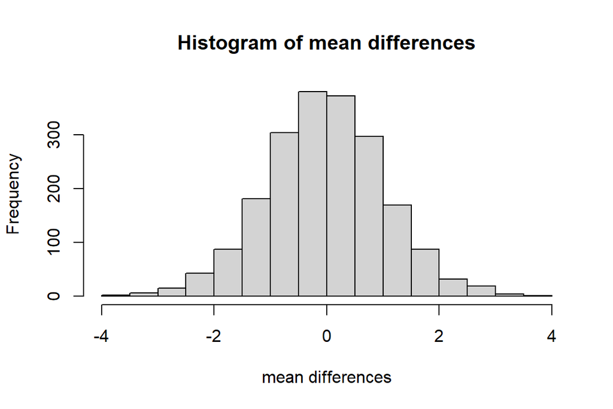

- **Q5 (2 pts.): How many of your resampled differences of means had a magnitude greater than 5.8?**

*Answer: 0*

```r
sum(mean_differences > 5.8)
```

```
## [1] 0
```

## Resampling and p-values

- **Q6 (2 pts.): Given a p value of less than 1 per 10 million, how many simulations do you think you would have to do to see a difference in mean flipper length equal to or greater than 5.8 mm?**

*Answer: at least 10 million, this because we have a p value of 0.00000006, this mean that if we repeat the analysis with different set of data on 99.9999999% of the time we will see a different less that 5.8 mm, if we want to see a different greater than 5.8 mm we need to redo the analysis at leats 10 million of times.*

## Resampling a different variable

```
- Choose another variable of penguin data from dat_pen.

- Create a boxplot of the data from your chosen column in dat_pen, grouped by species.



- See the walkthrough for info.

- Use aggregate() to calculate the group means and the difference in means.

- Write the difference in means into a variable called diff_crit




- Conduct a t-test and observe the p-value.



- Conduct a resampling test with 1000 repetitions using your two_group_resample_diff() function.
```

- **Q7 (1 pt.): Include a boxplot of your chosen variable in your report.**

*Answer:*

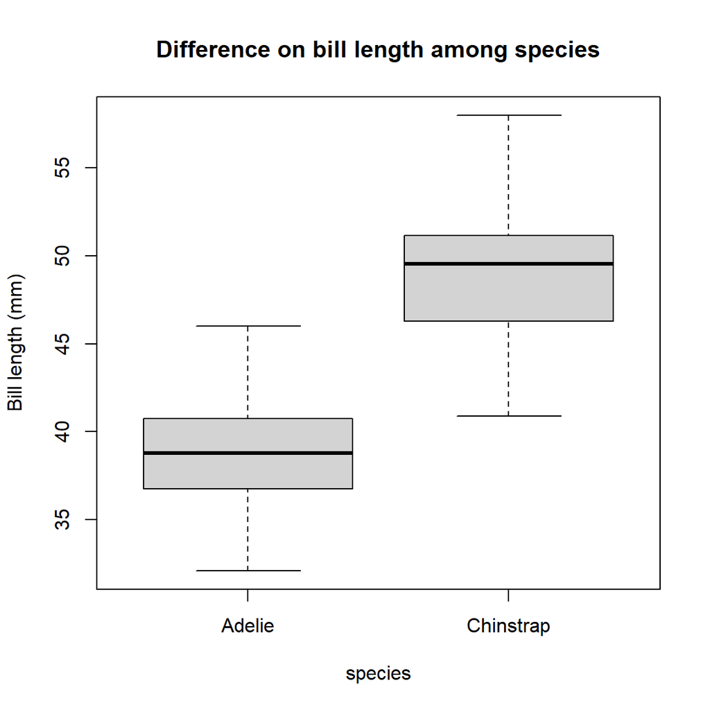

- **Q9 (4 pts.): Interpret the p-value from the t-test output in plain, non-technical English that a non-statistician would understand.**

*Answer: The p values is 2.2e-16, in normal number is 0.00000000000000022, this value due of the t-test suggests that there is good evidence that the bill length is different between the two species. Our P value is so low that, if we redoing the analysis with different set of data we will need much more than 100 millions of intents to found a different between bill length of penguins.*

*If we use the alpha value of 0.05 to interpret the p value, we could see that if we repeat the analysis with different set of data at least the 95% of the intent we will see a good evidence that the bill length is different between penguin species.*

- **Q10 (2 pts.): How many differences in means were greater than diff_crit?**
  - Remember to treat this as a 2-tailed test.

*Answer: Our diff_crit is 10.04243, and there are 0 diffences in means that were greater that 10.04243*

```r
sum(mean_differences > diff_crit)
```

```
## [1] 0
```

- **Q11 (1 pt.): Include a histogram of your simulation results in your report. Make sure it has appropriate title and labels.**

*Answer:*

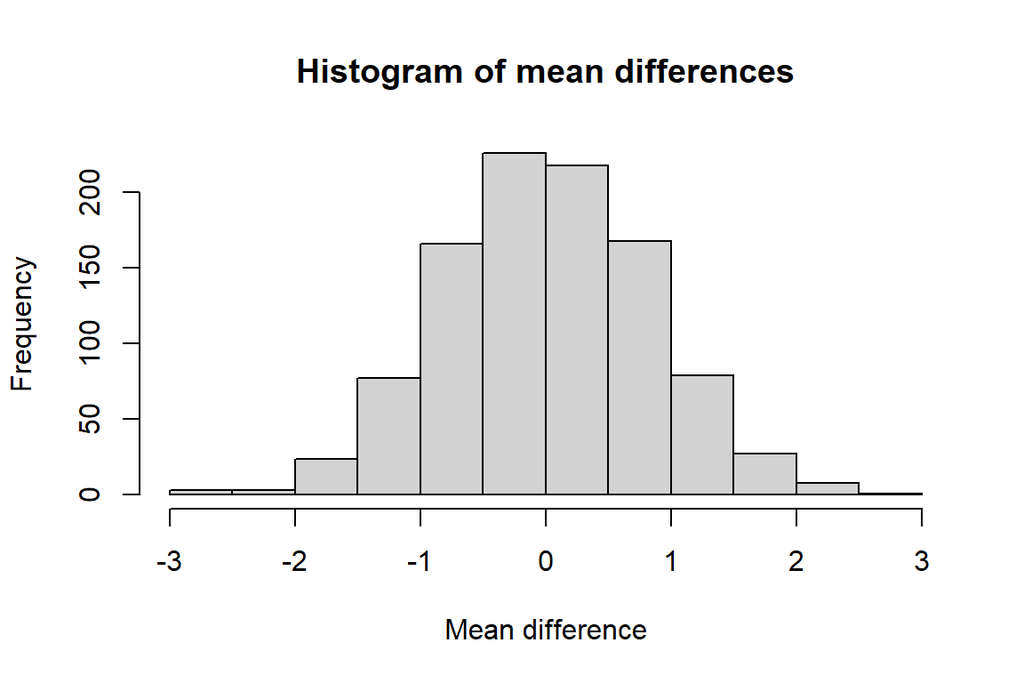